# Basic Data Visulisaion

Jesse

2019年9月16日

# Data Visulisation

As we did some basic analysis toward our data, we got some hypothesis.  
Thereafter, it’s time for us to visualize our hypothesis to test whether it’s true,  
and make it more easy to understand.

## Dataset

Dataset is the data we’re going to deal with. Normaly, there are 2 ways to import the dataset.

1. csv files.
2. library->dataset in it.

Currently, we are going to discuss about the first way.

After downloading the dataset, we can use `read.csv()` to import dataset.  
Regarding file path, we may use *absolute path* or *relative path* to import the files.

Absolute Path

```r
babies <- read.csv("C:/Users/asus/Desktop/TA/TA session/week1/babies.csv")
head(babies,10)
```

```
##    case bwt gestation parity age height weight smoke
## 1     1 120       284      0  27     62    100     0
## 2     2 113       282      0  33     64    135     0
## 3     3 128       279      0  28     64    115     1
## 4     4 123        NA      0  36     69    190     0
## 5     5 108       282      0  23     67    125     1
## 6     6 136       286      0  25     62     93     0
## 7     7 138       244      0  33     62    178     0
## 8     8 132       245      0  23     65    140     0
## 9     9 120       289      0  25     62    125     0
## 10   10 143       299      0  30     66    136     1
```

Relative Path

```r
babies <- read.csv("babies.csv")
head(babies,10)
```

```
##    case bwt gestation parity age height weight smoke
## 1     1 120       284      0  27     62    100     0
## 2     2 113       282      0  33     64    135     0
## 3     3 128       279      0  28     64    115     1
## 4     4 123        NA      0  36     69    190     0
## 5     5 108       282      0  23     67    125     1
## 6     6 136       286      0  25     62     93     0
## 7     7 138       244      0  33     62    178     0
## 8     8 132       245      0  23     65    140     0
## 9     9 120       289      0  25     62    125     0
## 10   10 143       299      0  30     66    136     1
```

## Plots

After importing dataset, it’s time to do some analysis.  
Today, we will use learn three kinds of plot.

1. Scatterplot
2. Histogram
3. Boxplot

Before conducting plots, we have to include *tidyverse* library so that we can do plots.  
`library(tidyverse)` so that we can use functions related to *ggplot* in it.

Firstly, that’s see our dataset, babies.

```r
head(babies,10)
```

```
##    case bwt gestation parity age height weight smoke
## 1     1 120       284      0  27     62    100     0
## 2     2 113       282      0  33     64    135     0
## 3     3 128       279      0  28     64    115     1
## 4     4 123        NA      0  36     69    190     0
## 5     5 108       282      0  23     67    125     1
## 6     6 136       286      0  25     62     93     0
## 7     7 138       244      0  33     62    178     0
## 8     8 132       245      0  23     65    140     0
## 9     9 120       289      0  25     62    125     0
## 10   10 143       299      0  30     66    136     1
```

### Scatterplot

We might want to see the correlation between weight and height.  
Under such circumstances, we can create a scatterplot with it.

Firstly, we create our graph and make R software know what dataset we are using.  
We can use`ggplot(data= THE NAME of THE DATASET)` to reach that.  
Then, the function geom_point() adds a layer of points to your plot.

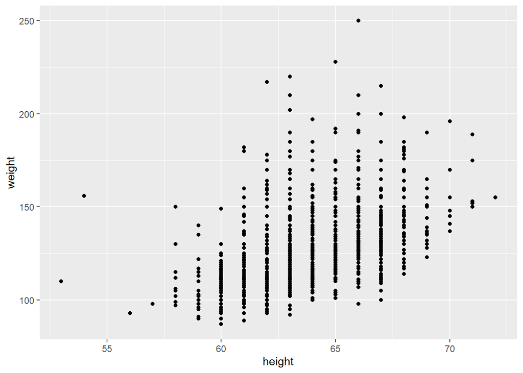

```r
ggplot(data=babies) +
  geom_point(mapping = aes(x = height, y = weight))
```

Just as the above function shows, *mapping* is always with *aes()*,  
and the x and y arguments what variables to map to the x and y axes.

### Histogram

Pretty similar to the scatterplot, we use `ggplot(data)` to create our graph. Thereafter, we use `geom_bar` and x arguments in it to map the counts of the variable.

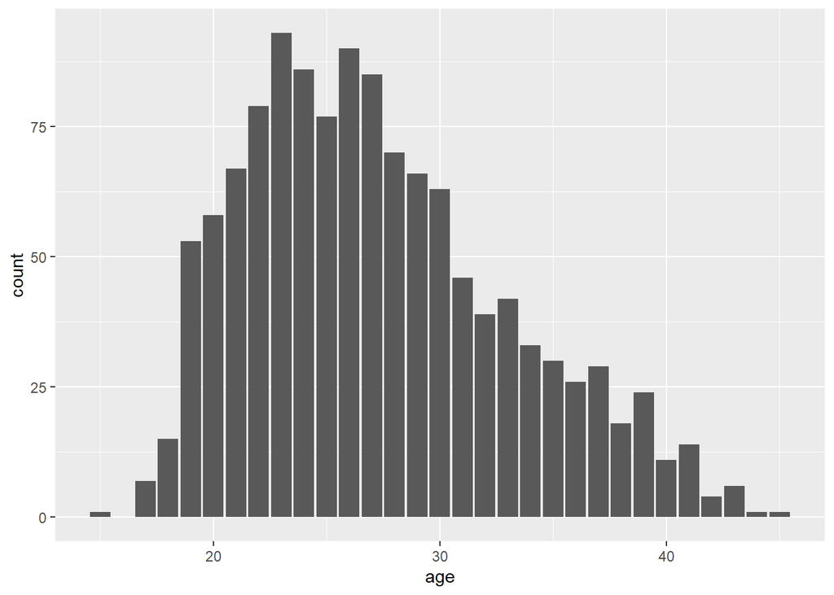

```r
ggplot(data = babies) +
  geom_bar(mapping = aes(x = age))
```

### Boxplot

Boxplot allow one to visually estimate various estimators, such as interquartle range, midhinge, range, mid-range and trimean. Key difference from the two scatterplot is that we need to `group` the variable in x arguments in `aes()` to ensure we can get the correct plot.

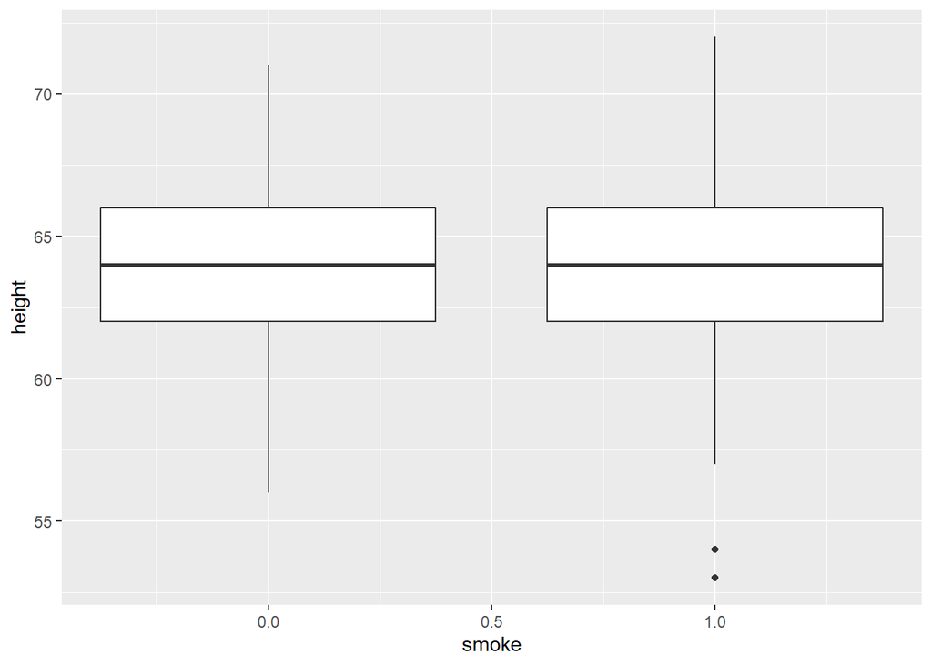

```r
ggplot(data = babies, mapping = aes(group = smoke,x= smoke, y = height)) +
  geom_boxplot()
```

#### Question

You can get several datasets from https://www.openintro.org/stat/data.php. Pick and download one dataset, conduct *scatterplot*, *histogram*, and *boxplot* of the variables you pick.